# Bixi Part 1: Pre-processing

Phan Vu-Hong-Hai

Last updated on 14 January, 2024

In this project, we’ll use the `data.table`, `tidyverse` and `knitr` library.

```r
library(data.table)
library(tidyverse)
library(knitr)
library(kableExtra)

# Remove the comments in the outputs
knitr::opts_chunk$set(comment=NA)
```

```r
ZIP_DATA <- file.path('data', 'zipfiles')
system(paste('tree', ZIP_DATA))
```

Next, unzip the zip files in the `data/zipfiles` folder using R’s `unzip()` functions. In this project, we will only work with the data from 2019 onward. The zipped data in the `data/zipfiles` is stored with the year value in the file names, thus, we can extract the year of data using `str_extract()` function. The newly extracted csv files will be stored in the `data/raw_csv/<year>` folders.

The extracted file names are stored by year in the `records` list variable for the later references.

```r
zip_files <- list.files(path=ZIP_DATA, pattern='*.zip', full.names=T)
records <- c()
for (zip_file in zip_files) {
    cat('Unzipping', zip_file, '\n')
    # Extract the year from the file path.
    year <-str_extract(zip_file, regex('\\d{4}'))
    csv_folder <- file.path('data', 'raw_csv', year)
    records[year] <- csv_folder
    # Check if the current file is already extracted.
    if (dir.exists(csv_folder))
      next
    unzip(zip_file, exdir=csv_folder)
}
```

```
Unzipping data/zipfiles/DonneesOuverte2022.zip
Unzipping data/zipfiles/DonneesOuvertes2023_10.zip
Unzipping data/zipfiles/Historique-BIXI-2019.zip
Unzipping data/zipfiles/Historique-BIXI-2020.zip
Unzipping data/zipfiles/Historique-BIXI-2021.zip
```

Now, we will have a quick look at the list of csv files from each year.

```r
years = names(records)
for (year in sort(years, decreasing=T)) {
    cat(year, '\n')
    print(list.files(records[year]))
}
```

```
2023
[1] "DonneesOuvertes.csv"
2022
[1] "DonneesOuverte2022.csv"
2021
[1] "2021_donnees_ouvertes.csv" "2021_stations.csv"
2020
[1] "OD_2020.csv"  "stations.csv"
2019
[1] "OD_2019-04.csv"    "OD_2019-05.csv"    "OD_2019-06.csv"
[4] "OD_2019-07.csv"    "OD_2019-08.csv"    "OD_2019-09.csv"
[7] "OD_2019-10.csv"    "Stations_2019.csv"
```

For two years `2023` and `2022`, the data is structured differently from the rest: there isn’t a station file. It hints that the station’s data is incoperated with the trips. We can confirm that by having a quick look at the datasets’ structure.

```r
for (year in c('2022', '2023')) {
  file_name <- list.files(records[year])
  file_path <- file.path(records[year], file_name)
  cat(year, '\t', file_name, '\n')
  # Print out the structure of the first 100 line from each dataset.
  str(fread(cmd=paste('head -n 100', file_path)))
}
```

```
2022     DonneesOuverte2022.csv
Classes 'data.table' and 'data.frame':  99 obs. of  10 variables:
 $ STARTSTATIONNAME          : chr  "St-Urbain / René-Lévesque" "Roy / St-Laurent" "Lajeunesse / Villeray" "Parc Plage" ...
 $ STARTSTATIONARRONDISSEMENT: chr  "Ville-Marie" "Le Plateau-Mont-Royal" "Villeray - Saint-Michel - Parc-Extension" "Ville-Marie" ...
 $ STARTSTATIONLATITUDE      : num  45.5 45.5 45.5 45.5 45.5 ...
 $ STARTSTATIONLONGITUDE     : num  -73.6 -73.6 -73.6 -73.5 -73.6 ...
 $ ENDSTATIONNAME            : chr  "Mansfield / Ste-Catherine" "Dorion / Rachel" "Leman / de Chateaubriand" "de la Commune / King" ...
 $ ENDSTATIONARRONDISSEMENT  : chr  "Ville-Marie" "Le Plateau-Mont-Royal" "Villeray - Saint-Michel - Parc-Extension" "Ville-Marie" ...
 $ ENDSTATIONLATITUDE        : num  45.5 45.5 45.5 45.5 45.5 ...
 $ ENDSTATIONLONGITUDE       : num  -73.6 -73.6 -73.6 -73.6 -73.6 ...
 $ STARTTIMEMS               :integer64 1653343831220 1653343831410 1653343832935 1653343837732 1653343832286 1653343832469 1653343836945 1653343847049 ...
 $ ENDTIMEMS                 :integer64 1653344213703 1653344969358 1653344101829 1653347197916 1653344140732 1653345495661 1653344669846 1653344690818 ...
 - attr(*, ".internal.selfref")=<externalptr>
2023     DonneesOuvertes.csv
Classes 'data.table' and 'data.frame':  99 obs. of  10 variables:
 $ STARTSTATIONNAME          : chr  "Gauthier / de Lorimier" "Métro Papineau (Dorion / De Maisonneuve)" "Bloomfield / Bernard" "Larivière / de Lorimier" ...
 $ STARTSTATIONARRONDISSEMENT: chr  "Le Plateau-Mont-Royal" "Ville-Marie" "Outremont" "Ville-Marie" ...
 $ STARTSTATIONLATITUDE      : num  45.5 45.5 45.5 45.5 45.5 ...
 $ STARTSTATIONLONGITUDE     : num  -73.6 -73.6 -73.6 -73.6 -73.6 ...
 $ ENDSTATIONNAME            : chr  "Métro Frontenac (Ontario / du Havre)" "Dorion / Ontario" "Jeanne-Mance / St-Viateur" "St-Hubert / de Maisonneuve (sud)" ...
 $ ENDSTATIONARRONDISSEMENT  : chr  "Ville-Marie" "Ville-Marie" "Le Plateau-Mont-Royal" "Ville-Marie" ...
 $ ENDSTATIONLATITUDE        : num  45.5 45.5 45.5 45.5 45.5 ...
 $ ENDSTATIONLONGITUDE       : num  -73.6 -73.6 -73.6 -73.6 -73.6 ...
 $ STARTTIMEMS               :integer64 1698248985976 1698256985216 1698259921562 1698258433474 1698261523775 1698262438176 1698255704388 1698255767574 ...
 $ ENDTIMEMS                 :integer64 1698249292475 1698257775613 1698260206417 1698259223584 1698264064195 1698263046472 1698256200030 1698256569501 ...
 - attr(*, ".internal.selfref")=<externalptr>
```

We can see that both datasets from `2022` and `2023` contain the station names, and station districts as strings. Which isn’t efficient for our analysis purposes. Therefore, in the next step, we’ll de-couple the stations’ names, districts, latitudes, and longitudes from the trip data and denote them as station IDs instead. In the datasets from `2021` and `2020`, the trip data and station data are already decoupled. Lastly, in the data from `2019`, there are data from multiple months that should be joined together to make a whole year dataset.

Based on that observation, we’ll have 3 chapters: 1) the `2023` and `2022` datasets, 2) the `2021` and `2020` datasets, and 3) the `2019` dataset.

## 1. The 2023 and 2022 dataset.

### 1.1 The 2023 dataset.

In this project, we will utilize `data.table` library for storing dataframes and performing complex data wrangling tasks for its efficiency. In cases of light computation, standard `data.frames` operations are used for their aesthetics.

```r
data_2023 <- fread(file=file.path(records['2023'], 'DonneesOuvertes.csv'))
str(data_2023)
```

```
Classes 'data.table' and 'data.frame':  11045591 obs. of  10 variables:
 $ STARTSTATIONNAME          : chr  "Gauthier / de Lorimier" "Métro Papineau (Dorion / De Maisonneuve)" "Bloomfield / Bernard" "Larivière / de Lorimier" ...
 $ STARTSTATIONARRONDISSEMENT: chr  "Le Plateau-Mont-Royal" "Ville-Marie" "Outremont" "Ville-Marie" ...
 $ STARTSTATIONLATITUDE      : num  45.5 45.5 45.5 45.5 45.5 ...
 $ STARTSTATIONLONGITUDE     : num  -73.6 -73.6 -73.6 -73.6 -73.6 ...
 $ ENDSTATIONNAME            : chr  "Métro Frontenac (Ontario / du Havre)" "Dorion / Ontario" "Jeanne-Mance / St-Viateur" "St-Hubert / de Maisonneuve (sud)" ...
 $ ENDSTATIONARRONDISSEMENT  : chr  "Ville-Marie" "Ville-Marie" "Le Plateau-Mont-Royal" "Ville-Marie" ...
 $ ENDSTATIONLATITUDE        : num  45.5 45.5 45.5 45.5 45.5 ...
 $ ENDSTATIONLONGITUDE       : num  -73.6 -73.6 -73.6 -73.6 -73.6 ...
 $ STARTTIMEMS               :integer64 1698248985976 1698256985216 1698259921562 1698258433474 1698261523775 1698262438176 1698255704388 1698255767574 ...
 $ ENDTIMEMS                 :integer64 1698249292475 1698257775613 1698260206417 1698259223584 1698264064195 1698263046472 1698256200030 1698256569501 ...
 - attr(*, ".internal.selfref")=<externalptr>
```

As confirmed in the previous quick peek at the data, the columns `STARTSTATIONNAME`, `STARTSTATIONARRONDISSEMENT`, `ENDSTATIONNAME`, and `ENDSTATIONNAME` are all stored as strings, which is a quite inefficient use of memory for the data analysis purpose. Therefore, I’ll split the data frame into 2 different dataframes. The first one contains the trip data: start station ID, start time, end station ID, and end time. The second one contains the station information: station ID, station name, station district, station latitude, and station longitude.

Firstly, the column will be renamed for the sake of consistency. Also, all of the string columns (`chr` type) will be changed to `factor` datatype in R, which makes working with the data more efficient.

```r
data_2023_renamed <- data_2023 %>%
  mutate_if(is.character, trimws) %>% # Remove leading and trailing white spaces
  mutate_if(is.character, as.factor) %>% # Change string datatype to R's factor
  rename(start_station=STARTSTATIONNAME,
    start_station_district=STARTSTATIONARRONDISSEMENT,
    start_station_lat=STARTSTATIONLATITUDE,
    start_station_long=STARTSTATIONLONGITUDE,
    end_station=ENDSTATIONNAME,
    end_station_district=ENDSTATIONARRONDISSEMENT,
    end_station_lat=ENDSTATIONLATITUDE,
    end_station_long=ENDSTATIONLONGITUDE,
    start_time=STARTTIMEMS,
    end_time=ENDTIMEMS)
```

Now, we’ll extract all the distinct values of `station_name`, `lat`, `long`, and `district` from both the start stations and end stations.

```r
start_stations_2023 <- data_2023_renamed %>%
  select(station_name=start_station,
         lat=start_station_lat,
         long=start_station_long,
         district=start_station_district) %>%
  distinct()

end_stations_2023 <- data_2023_renamed %>%
  select(station_name=end_station,
         lat=end_station_lat,
         long=end_station_long,
         district=end_station_district) %>%
  distinct()
```

The stations’ information is now can be bound into a dataframe named `all_stations_2023`.

```r
all_stations_2023 <- rbind(start_stations_2023, end_stations_2023) %>%
    distinct()
```

Next, let’s check for duplicated using latitude and longitude. We can see that there are 19 coordinates that have at least 2 different station names.

```r
duplicated_coord_2023 <- all_stations_2023 %>%
                           count(lat, long) %>%
                           filter(n > 1)

sprintf('Number of duplicated coordinates: %d', nrow(duplicated_coord_2023))
```

```
[1] "Number of duplicated coordinates: 19"
```

To extract the stations with duplicate coordinates, we can inner join the `duplicated_coord_2023` with the original data.

```r
duplicated_2023 <- duplicated_coord_2023[all_stations_2023, on=.(lat=lat, long=long),
                                         nomatch=0] %>%
                     arrange(cbind(lat, long)) %>%
                     select(lat, long, station_name)

# Display as scroll-able HTML box
# Same group stations are denoted using a same color
to_kbl <- duplicated_2023 %>%
  group_by(lat, long) %>%
  mutate(group_id=cur_group_id())

kbl(to_kbl %>% select(-group_id)) %>%
  kable_paper() %>%
  column_spec(1:3, background=ifelse(to_kbl$group_id%%2==1, '#84dcc6', '#a5ffd6')) %>%
  scroll_box(width='100%', height='450px')
```

| lat | long | station_name |
| --- | --- | --- |
| 45.48820 | -73.58807 | de Maisonneuve / Wood |
| 45.48820 | -73.58807 | Maisonneuve / Wood |
| 45.49130 | -73.56160 | Ottawa / du Séminaire |
| 45.49130 | -73.56160 | Ottawa / Séminaire |
| 45.49859 | -73.57428 | Ste-Catherine / Drummond |
| 45.49859 | -73.57428 | Ste-Cathrine / Drummond |
| 45.50229 | -73.57331 | de Maisonneuve / Mansfield (sud-est) |
| 45.50229 | -73.57331 | de Maisonneuve / Mansfield SE |
| 45.50956 | -73.55741 | de l’Hôtel-de-Ville / Viger |
| 45.50956 | -73.55741 | de l’hôtel de Ville / Viger N/E |
| 45.51077 | -73.56494 | Métro St-Laurent ( de Maisonneuve / St-Laurent) |
| 45.51077 | -73.56494 | Métro St-Laurent 2 ( de Maisonneuve / St-Laurent) |
| 45.51280 | -73.53112 | Parc Jean-Drapeau (Chemin Macdonald) |
| 45.51280 | -73.53112 | Métro Jean-Drapeau |
| 45.51863 | -73.56113 | St-Timothée / Robin |
| 45.51863 | -73.56113 | St-Timothé / Robin |
| 45.51990 | -73.58011 | de l’Hôtel-de-Ville / Rachel |
| 45.51990 | -73.58011 | de l’Hotel-de-Ville / Rachel |
| 45.52002 | -73.61891 | CCI Outremont (Dollard / Ducharme) |
| 45.52002 | -73.61891 | CCI Outremont (Dollard / Durcharme) |
| 45.52712 | -73.54802 | Parc Hector-Toe-Blake ( Sussex / René-Levesque ) |
| 45.52712 | -73.54802 | Fullum / Ste-Catherine |
| 45.52950 | -73.60486 | Henri-Julien / de Bellechasse |
| 45.52950 | -73.60486 | St-Dominique / de Bellechasse |
| 45.52970 | -73.58289 | Christophe Colomb / Gilford |
| 45.52970 | -73.58289 | Christophe-Colomb / Gilford |
| 45.53236 | -73.58463 | Brébeuf / Laurier |
| 45.53236 | -73.58463 | Laurier / Brébeuf |
| 45.53935 | -73.59537 | de Bellechasse / de Lanaudière |
| 45.53935 | -73.59537 | Parc Père-Marquette ( de Bellechasse / de Lanaudière) |
| 45.54730 | -73.64587 | Parc Henri-Julien (St-Denis / Legendre) |
| 45.54730 | -73.64587 | 6917 Parc Henri-Julien (St-Denis / Legendre) |
| 45.55679 | -73.55465 | Jardin Botanique Dépôt Fierté (Sherbrooke / Pie-IX) |
| 45.55679 | -73.55465 | Jardin Botanique dépôt fierté (Sherbrooke / Pie-IX) |
| 45.55679 | -73.55465 | Jardin Botanique (Sherbrooke / Pie-IX) |
| 45.56169 | -73.61051 | Parc Howard (de l’Épée / de Liège) |
| 45.56169 | -73.61051 | CHSLD St-Michel (8e avenue / Jarry) |
| 45.56481 | -73.59580 | Parc Joseph-Robin (18e avenue / Everett) |
| 45.56481 | -73.59580 | 8e avenue / Everett |

My guess is that it can caused by legacy naming, or multiple kiosks at the same coordinate. For any reason, we can merge the stations which have the same coordinate together. The station ID is created using the row number.

```r
all_stations_2023_final <- all_stations_2023 %>%
                             distinct(lat, long, .keep_all = TRUE) %>%
                             mutate(id=1:nrow(.))
```

Now the stations dataframe is ready, we can join it back with the original dataset to have the `id` of start stations and end stations. In this case, I’ll use the `data.table`‘s joining method and left join the `data_2023_renamed` to the stations’ data using `lat` and `long` as keys. Finally, we can have a quick view of the new dataframe that contains `id` of the start and end stations.

```r
station_to_merge_2023 <- all_stations_2023_final %>%
                          select(lat, long, id)
data_2023_renamed_ided <- data_2023_renamed[station_to_merge_2023,
                                            on=.(start_station_lat=lat,
                                                start_station_long=long)] %>%
                            rename(start_station_id=id)
data_2023_renamed_ided <- data_2023_renamed_ided[station_to_merge_2023,
                                                  on=.(end_station_lat=lat,
                                                       end_station_long=long)] %>%
                            rename(end_station_id=id)
str(data_2023_renamed_ided)
```

```
Classes 'data.table' and 'data.frame':  11045592 obs. of  12 variables:
 $ start_station         : Factor w/ 935 levels "","10e avenue / Masson",..: 373 373 373 373 373 373 373 373 373 373 ...
 $ start_station_district: Factor w/ 26 levels "","Ahuntsic-Cartierville",..: 9 9 9 9 9 9 9 9 9 9 ...
 $ start_station_lat     : num  45.5 45.5 45.5 45.5 45.5 ...
 $ start_station_long    : num  -73.6 -73.6 -73.6 -73.6 -73.6 ...
 $ end_station           : Factor w/ 936 levels "","10e avenue / Masson",..: 373 373 373 373 373 373 373 373 373 373 ...
 $ end_station_district  : Factor w/ 26 levels "","Ahuntsic-Cartierville",..: 9 9 9 9 9 9 9 9 9 9 ...
 $ end_station_lat       : num  45.5 45.5 45.5 45.5 45.5 ...
 $ end_station_long      : num  -73.6 -73.6 -73.6 -73.6 -73.6 ...
 $ start_time            :integer64 1691291322751 1685194000412 1685195954939 1696288077327 1695904068657 1695918155359 1695834352582 1683687740337 ...
 $ end_time              :integer64 1691291412042 1685194599455 1685196229500 1696288201640 1695904105222 1695918734977 1695834417705 1683688379037 ...
 $ start_station_id      : int  1 1 1 1 1 1 1 1 1 1 ...
 $ end_station_id        : int  1 1 1 1 1 1 1 1 1 1 ...
 - attr(*, ".internal.selfref")=<externalptr>
```

The trip data will now only contain `start_station_id`, `start_time`, `end_station_id`, and `end_time`.

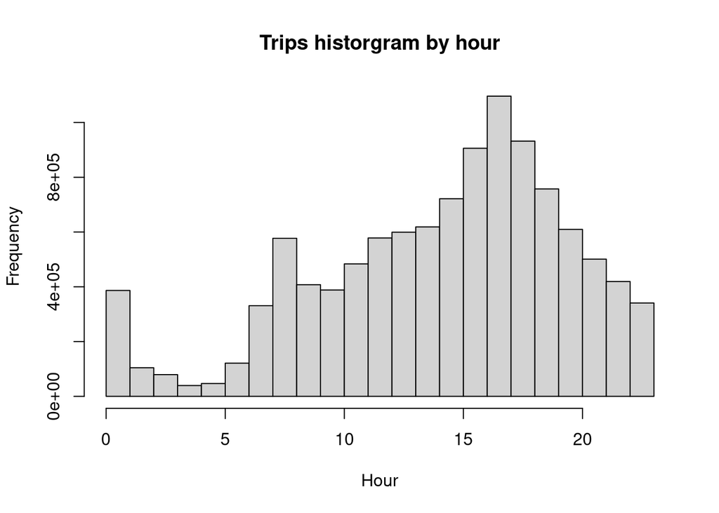

```r
trips_2023_final <- data_2023_renamed_ided %>%
                      select(start_station_id, start_time, end_station_id, end_time) %>%
                      mutate(start_time=as.POSIXct(start_time/1000, origin='1970-01-01',
                                                   tz='America/Toronto')) %>%
                      mutate(end_time=as.POSIXct(end_time/1000, origin='1970-01-01',
                                                 tz='America/Toronto'))

hist(hour(trips_2023_final[, start_time]),
     main='Trips historgram by hour',
     xlab='Hour')
```

Finally, we’ll store the cleaned data in the `data/processed` folders with the names `trips_2023.csv` and `stations_2023.csv` for trip data and station data respectively.

```r
processed_folder <- file.path('data', 'processed')
# If the data/processed folder doesn't exist, create one.
if (!dir.exists(processed_folder)){
  dir.create(processed_folder)
}

# To keep the timestamps as-is without changing the system's timezone,
# we use dateTimeAs='write.csv'
fwrite(trips_2023_final, file.path(processed_folder, 'trips_2023.csv'),
       dateTimeAs='write.csv')
fwrite(all_stations_2023_final, file.path(processed_folder, 'stations_2023.csv'),
       dateTimeAs='write.csv')
```

Bonus, let’s check the size of the objects used for this dataset.

```r
objects_2023 <- ls()[grepl('2023', ls())]
print(sapply(objects_2023, function(x) {
        format(object.size(get(x)), units='auto') }))
```

```
      all_stations_2023 all_stations_2023_final               data_2023
             "111.2 Kb"              "114.5 Kb"              "842.9 Mb"
      data_2023_renamed  data_2023_renamed_ided         duplicated_2023
             "674.3 Mb"              "758.6 Mb"               "87.6 Kb"
  duplicated_coord_2023       end_stations_2023     start_stations_2023
                 "2 Kb"              "111.2 Kb"              "111.1 Kb"
  station_to_merge_2023        trips_2023_final
              "19.4 Kb"              "252.8 Mb"
```

We managed to scale down the 2023 data from `842.9 Mb` to around `253 Mb`. At this step, we can clear all these objects.

```r
rm(list=objects_2023)
```

### 1.2 The 2022 dataset.

This dataset is quite similar to the 2023’s. First, let’s see what we have by loading the dataset into R’s dataframe.

```r
data_2022 <- fread(file=file.path(records['2022'], 'DonneesOuverte2022.csv'))
str(data_2022)
```

```
Classes 'data.table' and 'data.frame':  8967927 obs. of  10 variables:
 $ STARTSTATIONNAME          : chr  "St-Urbain / René-Lévesque" "Roy / St-Laurent" "Lajeunesse / Villeray" "Parc Plage" ...
 $ STARTSTATIONARRONDISSEMENT: chr  "Ville-Marie" "Le Plateau-Mont-Royal" "Villeray - Saint-Michel - Parc-Extension" "Ville-Marie" ...
 $ STARTSTATIONLATITUDE      : num  45.5 45.5 45.5 45.5 45.5 ...
 $ STARTSTATIONLONGITUDE     : num  -73.6 -73.6 -73.6 -73.5 -73.6 ...
 $ ENDSTATIONNAME            : chr  "Mansfield / Ste-Catherine" "Dorion / Rachel" "Leman / de Chateaubriand" "de la Commune / King" ...
 $ ENDSTATIONARRONDISSEMENT  : chr  "Ville-Marie" "Le Plateau-Mont-Royal" "Villeray - Saint-Michel - Parc-Extension" "Ville-Marie" ...
 $ ENDSTATIONLATITUDE        : num  45.5 45.5 45.5 45.5 45.5 ...
 $ ENDSTATIONLONGITUDE       : num  -73.6 -73.6 -73.6 -73.6 -73.6 ...
 $ STARTTIMEMS               :integer64 1653343831220 1653343831410 1653343832935 1653343837732 1653343832286 1653343832469 1653343836945 1653343847049 ...
 $ ENDTIMEMS                 :integer64 1653344213703 1653344969358 1653344101829 1653347197916 1653344140732 1653345495661 1653344669846 1653344690818 ...
 - attr(*, ".internal.selfref")=<externalptr>
```

This time, we have 8.9 million records, instead of 11 million records as in 2023. Other than that, the structure is similar. So we’ll continue by changing the string datatype to factor, then change the columns’ names.

```r
data_2022_renamed <- data_2022 %>%
  mutate_if(is.character, trimws) %>% # Remove leading and trailing whitespaces
  mutate_if(is.character, as.factor) %>% # Change string datatype to R's factor
  rename(start_station=STARTSTATIONNAME,
    start_station_district=STARTSTATIONARRONDISSEMENT,
    start_station_lat=STARTSTATIONLATITUDE,
    start_station_long=STARTSTATIONLONGITUDE,
    end_station=ENDSTATIONNAME,
    end_station_district=ENDSTATIONARRONDISSEMENT,
    end_station_lat=ENDSTATIONLATITUDE,
    end_station_long=ENDSTATIONLONGITUDE,
    start_time=STARTTIMEMS,
    end_time=ENDTIMEMS)
```

All of the stations are extracted from the data in a similar fashion as the 2023’s.

```r
start_stations_2022 <- data_2022_renamed %>%
  select(start_station, start_station_lat, start_station_long, start_station_district) %>%
  distinct() %>%
  setnames(new=c('station_name', 'lat', 'long', 'district'))

end_stations_2022 <- data_2022_renamed %>%
  select(end_station, end_station_lat, end_station_long, end_station_district) %>%
  distinct() %>%
  setnames(new=c('station_name', 'lat', 'long', 'district'))

all_stations_2022 <- rbind(start_stations_2022, end_stations_2022) %>%
    distinct()
```

Now let’s check the duplicated coordinated.

```r
duplicated_coord_2022 <- all_stations_2022 %>%
                          count(lat, long) %>%
                          filter(n > 1)

sprintf('Number of duplicated coordinates: %d', nrow(duplicated_coord_2022))
```

```
[1] "Number of duplicated coordinates: 10"
```

```r
duplicated_2022 <- duplicated_coord_2022[all_stations_2022, on=.(lat=lat, long=long),
                                         nomatch=0] %>%
                     arrange(cbind(lat, long)) %>%
                     select(lat, long, station_name)

to_kbl <- duplicated_2022 %>%
  group_by(lat, long) %>%
  mutate(group_id=cur_group_id())

kbl(to_kbl %>% select(-group_id)) %>%
  kable_paper() %>%
  column_spec(1:3, background=ifelse(to_kbl$group_id%%2==1, '#84dcc6', '#a5ffd6')) %>%
  scroll_box(width='100%', height='450px')
```

| lat | long | station_name |
| --- | --- | --- |
| 45.46977 | -73.58926 | Ste-Émilie / St-Rémi |
| 45.46977 | -73.58926 | St-Rémi / Ste Émilie |
| 45.51069 | -73.56531 | Métro St-Laurent Dépôt ( de Maisonneuve / St-Laurent) |
| 45.51069 | -73.56531 | Dépôt Festivals ( de Maisonneuve / St-Laurent) |
| 45.51613 | -73.56050 | St-Hubert /de Maisonneuve |
| 45.51613 | -73.56050 | St-Hubert / de Maisonneuve (nord) |
| 45.52080 | -73.57580 | Duluth / St-Denis |
| 45.52080 | -73.57580 | Quentin Gouvier (Duluth / St-Denis) |
| 45.52624 | -73.54895 | Sainte-Catherine / Parthenais |
| 45.52624 | -73.54895 | Ste-Catherine / Parthenais |
| 45.52950 | -73.60486 | St-Dominique / de Bellechasse |
| 45.52950 | -73.60486 | Henri-Julien / de Bellechasse |
| 45.54814 | -73.54713 | Parc Lalancette (de Rouen/ Valois) |
| 45.54814 | -73.54713 | Parc Lalancette (de Rouen / Valois) |
| 45.56169 | -73.61051 | Parc Howard (de l’Épée / de Liège) |
| 45.56169 | -73.61051 | CHSLD St-Michel (8e avenue / Jarry) |
| 45.56481 | -73.59580 | 8e avenue / Everett |
| 45.56481 | -73.59580 | Parc Tino-Rossi (18e avenue / Everett) |
| 45.56481 | -73.59580 | Parc Joseph-Robin (18e avenue / Everett) |
| 45.56844 | -73.67520 | Parc Henri-Dunant (Léger / Henri-Dunant) |
| 45.56844 | -73.67520 | Parc Henri-Durant (Léger / Henri-Durant) |

This time, we only have 10 coordinates that have more than 1 station name. Now we’ll select all distinct stations (by latitude and longitude) and save them to `all_stations_2022_final` dataframe. This time, we also have a station without values, and we should keep it, too.

```r
all_stations_2022_final <- all_stations_2022 %>%
                             distinct(lat, long, .keep_all = TRUE) %>%
                             mutate(id=1:nrow(.))
```

Now the stations dataframe is ready, we can join it back with the original dataset to have the `id` of the start stations and end stations.

```r
station_to_merge_2022 <- all_stations_2022_final %>%
                           select(lat, long, id)
data_2022_renamed_ided <- data_2022_renamed[station_to_merge_2022,
                                            on=.(start_station_lat=lat,
                                                start_station_long=long)] %>%
                            rename(start_station_id=id)
data_2022_renamed_ided <- data_2022_renamed_ided[station_to_merge_2022,
                                                  on=.(end_station_lat=lat,
                                                       end_station_long=long)] %>%
                            rename(end_station_id=id)
str(data_2022_renamed_ided)
```

```
Classes 'data.table' and 'data.frame':  8967927 obs. of  12 variables:
 $ start_station         : Factor w/ 868 levels "","10e avenue / Holt",..: 812 812 812 812 812 812 812 812 812 812 ...
 $ start_station_district: Factor w/ 23 levels "","Ahuntsic-Cartierville",..: 21 21 21 21 21 21 21 21 21 21 ...
 $ start_station_lat     : num  45.5 45.5 45.5 45.5 45.5 ...
 $ start_station_long    : num  -73.6 -73.6 -73.6 -73.6 -73.6 ...
 $ end_station           : Factor w/ 868 levels "","10e avenue / Holt",..: 812 812 812 812 812 812 812 812 812 812 ...
 $ end_station_district  : Factor w/ 23 levels "","Ahuntsic-Cartierville",..: 21 21 21 21 21 21 21 21 21 21 ...
 $ end_station_lat       : num  45.5 45.5 45.5 45.5 45.5 ...
 $ end_station_long      : num  -73.6 -73.6 -73.6 -73.6 -73.6 ...
 $ start_time            :integer64 1653346459372 1653346482125 1653598132965 1653331736653 1656552256783 1656567148478 1651356681448 1651593063901 ...
 $ end_time              :integer64 1653353008178 1653353010420 1653598423911 1653331751374 1656554101527 1656567301452 1651359197753 1651593107562 ...
 $ start_station_id      : int  1 1 1 1 1 1 1 1 1 1 ...
 $ end_station_id        : int  1 1 1 1 1 1 1 1 1 1 ...
 - attr(*, ".internal.selfref")=<externalptr>
```

Next, as for the 2023 dataset, we’ll use the `America/Toronto` timezone to convert the millisecond Unix epoch to the `YY-MM-DD HH:MM:SS` format. We’ll also need to plot a histogram of trip frequency by hour for timezone confirmation.

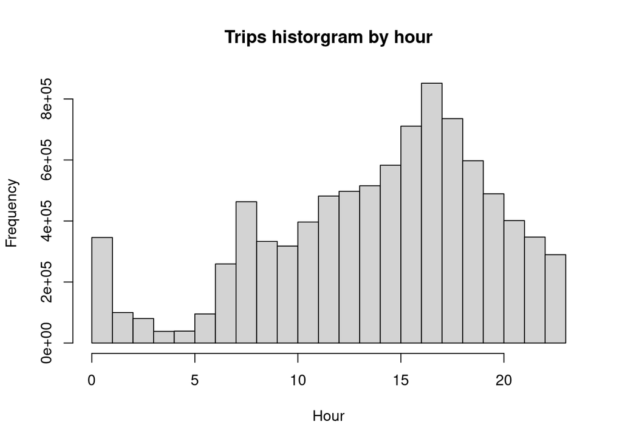

```r
trips_2022_final <- data_2022_renamed_ided %>%
                      select(start_station_id, start_time, end_station_id, end_time) %>%
                      mutate(start_time=as.POSIXct(start_time/1000, origin='1970-01-01',
                                                   tz='America/Toronto')) %>%
                      mutate(end_time=as.POSIXct(end_time/1000, origin='1970-01-01',
                                                 tz='America/Toronto'))

hist(hour(trips_2022_final[, start_time]),
     main='Trips historgram by hour',
     xlab='Hour')
```

Now we can store the data into the trips and stations data in csv format in the `data/processed` folder.

```r
# processed_folder <- file.path('data', 'processed')
# If the data/processed folder doesn't exist, create one.
if (!dir.exists(processed_folder)){
  dir.create(processed_folder)
}

# To keep the timestamps as-is without changing the system's timezone,
# we use dateTimeAs='write.csv'
fwrite(trips_2022_final, file.path(processed_folder, 'trips_2022.csv'),
       dateTimeAs='write.csv')
fwrite(all_stations_2022_final, file.path(processed_folder, 'stations_2022.csv'),
       dateTimeAs='write.csv')
```

Finally, let’s check the dataframe’s size and remove the unused ones.

```r
objects_2022 <- ls()[grepl('2022', ls())]
print(sapply(objects_2022, function(x) {
        format(object.size(get(x)), units='auto') }))
```

```
      all_stations_2022 all_stations_2022_final               data_2022
               "103 Kb"              "106.2 Kb"              "684.3 Mb"
      data_2022_renamed  data_2022_renamed_ided         duplicated_2022
             "547.5 Mb"              "615.9 Mb"               "80.8 Kb"
  duplicated_coord_2022       end_stations_2022     start_stations_2022
               "1.9 Kb"              "103.1 Kb"              "103.1 Kb"
  station_to_merge_2022        trips_2022_final
              "18.2 Kb"              "205.3 Mb"
```

```r
rm(list=objects_2022)
```

## 2. The 2021 and 2020 dataset.

### 2.1 The 2021 dataset.

This dataset is better structured with the trips and stations in separate files.

```r
list.files(records['2021'])
```

```
[1] "2021_donnees_ouvertes.csv" "2021_stations.csv"
```

Let’s have a look at the dataframes’ structure.

```r
trips_2021 <- fread(file=file.path(records['2021'], '2021_donnees_ouvertes.csv'))
stations_2021 <- fread(file=file.path(records['2021'], '2021_stations.csv'))
cat('Trips data', '\n')
```

```
Trips data
```

```r
str(trips_2021)
```

```
Classes 'data.table' and 'data.frame':  5566351 obs. of  6 variables:
 $ start_date          : POSIXct, format: "2021-06-29 17:46:28" "2021-04-25 18:02:39" ...
 $ emplacement_pk_start: int  10 10 10 10 10 10 10 10 10 10 ...
 $ end_date            : POSIXct, format: "2021-06-29 19:33:25" "2021-04-25 18:13:26" ...
 $ emplacement_pk_end  : int  10 188 778 504 780 185 153 10 186 10 ...
 $ duration_sec        : int  6417 647 505 2116 1743 1300 2745 82 1395 2184 ...
 $ is_member           : int  0 0 1 1 1 1 1 1 1 0 ...
 - attr(*, ".internal.selfref")=<externalptr>
```

```r
cat('Station data', '\n')
```

```
Station data
```

```r
str(stations_2021)
```

```
Classes 'data.table' and 'data.frame':  829 obs. of  4 variables:
 $ pk       : int  10 13 17 21 31 36 38 43 47 60 ...
 $ name     : chr  "Métro Angrignon (Lamont /  des Trinitaires)" "Métro de l'Église (Ross / de l'Église)" "Tolhurst / Fleury" "St-Christophe / Cherrier" ...
 $ latitude : num  45.4 45.5 45.5 45.5 45.5 ...
 $ longitude: num  -73.6 -73.6 -73.7 -73.6 -73.6 ...
 - attr(*, ".internal.selfref")=<externalptr>
```

For 2021, we have around 5.5 million trips. Other than the stations and timestamps, this trip data also contains `duration_sec` and `is_member`. The timestamps are properly stored in the `YY-MM-DD HH:MM:SS` format. From the structure, we can see that `pk` column will now be the stations’ ID.

As usual, I’ll start will the name changing.

```r
trips_2021_renamed <- trips_2021 %>%
                        rename(start_station_id=emplacement_pk_start,
                               start_time=start_date,
                               end_station_id=emplacement_pk_end,
                               end_time=end_date)
stations_2021_renamed <- stations_2021 %>%
                           rename(id=pk,
                                  station=name,
                                  lat=latitude,
                                  long=longitude)
```

Now let’s check if there’s any coordinate redundancy in the station data.

```r
duplicated_coord_2021 <- stations_2021_renamed %>%
                           count(lat, long) %>%
                           filter(n > 1)

sprintf('Number of duplicated coordinates: %d', nrow(duplicated_coord_2021))
```

```
[1] "Number of duplicated coordinates: 28"
```

```r
duplicated_2021 <- duplicated_coord_2021[stations_2021_renamed, on=.(lat=lat, long=long),
                                         nomatch=0] %>%
                     arrange(cbind(lat, long)) %>%
                     select(id, lat, long, station, n)
glimpse(duplicated_2021)
```

```
Rows: 59
Columns: 5
$ id      <int> 940, 1011, 969, 973, 981, 994, 1029, 1137, 367, 1069, 1019, 10…
$ lat     <dbl> 45.43356, 45.43356, 45.47188, 45.47188, 45.47256, 45.47256, 45…
$ long    <dbl> -73.68404, -73.68404, -73.53798, -73.53798, -73.56999, -73.569…
$ station <chr> "St-Joseph /21e avenue Lachine", "St-Joseph / 21e avenue Lachi…
$ n       <int> 2, 2, 2, 2, 2, 2, 2, 2, 2, 2, 2, 2, 2, 2, 2, 2, 2, 2, 3, 3, 3,…
```

So first, we’ll need to extract the `id`s that we want to replace, as well as the `id`s that replace them. And apply a mapping transition to our latest dataframe: `trips_2021_renamed`. Since we already have the `duplicated_2021` dataframe that contains the stations that have the same coordinate, we can use self-join on the same `lat` and `long` values, with the join’s left-hand size `id` greater than the other one. The result after this step can be as follows.

| old_id | new_id | number_of_duplicates |
| --- | --- | --- |
| id2 | id1 | 2 |
| id4 | id3 | 3 |
| id5 | id3 | 3 |
| id5 | id4 | 3 |

To avoid that, we can simply use `distinct()` to remove any duplicated `id` belonging to the to-be-replaced group.

```r
id_changes_2021 <- duplicated_2021[duplicated_2021, .(x.id, i.id),
                                        on=.(lat=lat, long=long, id>id), nomatch=0] %>%
                          rename(old=x.id, new=i.id) %>%
                          distinct(old, .keep_all=T)
glimpse(id_changes_2021)
```

```
Rows: 31
Columns: 2
$ old <int> 1011, 973, 994, 1137, 1069, 1030, 992, 1015, 954, 978, 1139, 1007,…
$ new <int> 940, 969, 981, 1029, 367, 1019, 991, 1014, 951, 977, 977, 990, 102…
```

After obtaining the `id`s for changing in the `id_changes_2021` dataframe, we can change the corresponding `id`s in `trips_2021_renamed` using update join procedures in `data.table`.

```r
trips_2021_final <- trips_2021_renamed
trips_2021_final[id_changes_2021, on=.(start_station_id=old), start_station_id:=new]
trips_2021_final[id_changes_2021, on=.(end_station_id=old), end_station_id:=new]
```

We also should remove the stations with duplicate coordinates in the `station_2021_renamed` dataframe. To ensure consistency of what station we want to keep, we should sort the rows by both `lat` and `long` and use `distinct()` to remove the duplicate.

```r
stations_2021_final <- stations_2021_renamed %>%
                         arrange(cbind(lat, long)) %>%
                         distinct(lat, long, .keep_all=T)
```

Now let’s plot the histogram by hour of the 2021’s trips and see if it’s similar to the one from the later years.

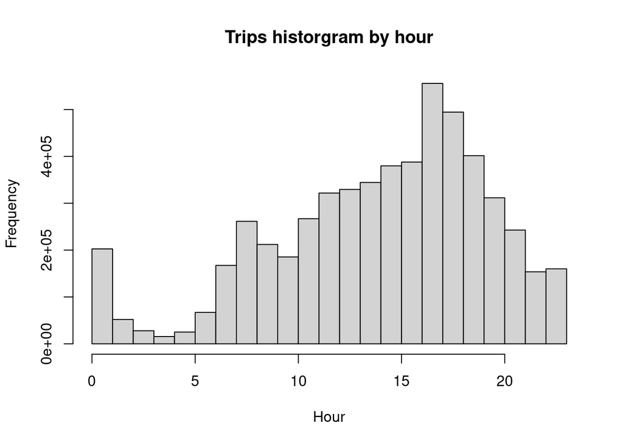

```r
hist(hour(trips_2021_final[, start_time]),
     main='Trips historgram by hour',
     xlab='Hour')
```

Finally, we can save the file to the `data/processed` folder.

```r
#processed_folder = file.path('data', 'processed')
if (!dir.exists(processed_folder)){
  dir.create(processed_folder)
}
fwrite(trips_2021_final, file.path(processed_folder, 'trips_2021.csv'))
fwrite(stations_2021_final, file.path(processed_folder, 'stations_2021.csv'))
```

As we are done working with this dataset, let’s remove the unused objects from the memory.

```r
objects_2021 <- ls()[grepl('2021', ls())]
print(sapply(objects_2021, function(x) {
        format(object.size(get(x)), units='auto') }))
```

```
      duplicated_2021 duplicated_coord_2021       id_changes_2021
             "8.7 Kb"              "2.1 Kb"              "1.6 Kb"
        stations_2021   stations_2021_final stations_2021_renamed
            "92.2 Kb"             "88.6 Kb"             "92.1 Kb"
           trips_2021      trips_2021_final    trips_2021_renamed
           "169.9 Mb"            "169.9 Mb"            "169.9 Mb"
```

```r
rm(list=objects_2021)
```

### 2.2 The 2020 dataset.

The 2020 dataset is similar to the 2021 dataset, with the trips and stations data coming in separated files and can be joined together using station ID.

```r
list.files(records['2020'])
```

```
[1] "OD_2020.csv"  "stations.csv"
```

Here are the dataframe’s structures.

```r
trips_2020 <- fread(file=file.path(records['2020'], 'OD_2020.csv'))
stations_2020 <- fread(file=file.path(records['2020'], 'stations.csv'))
cat('Trips data', '\n')
```

```
Trips data
```

```r
str(trips_2020)
```

```
Classes 'data.table' and 'data.frame':  3264741 obs. of  6 variables:
 $ start_date        : POSIXct, format: "2020-04-15 06:00:04" "2020-04-15 06:05:41" ...
 $ start_station_code: int  6212 6369 6207 6202 6159 7025 6929 6175 6250 6916 ...
 $ end_date          : POSIXct, format: "2020-04-15 06:20:54" "2020-04-15 06:32:47" ...
 $ end_station_code  : int  6250 6072 7038 6212 7067 6427 6255 7069 6183 6149 ...
 $ duration_sec      : int  1250 1626 724 572 885 2640 345 592 1032 207 ...
 $ is_member         : int  1 1 1 1 1 1 1 1 1 1 ...
 - attr(*, ".internal.selfref")=<externalptr>
```

```r
cat('Station data', '\n')
```

```
Station data
```

```r
str(stations_2020)
```

```
Classes 'data.table' and 'data.frame':  641 obs. of  4 variables:
 $ code     : int  6001 6002 6003 6004 6005 6006 6007 6008 6009 6901 ...
 $ name     : chr  "Métro Champ-de-Mars (Viger / Sanguinet)" "Ste-Catherine / Dezery" "Clark / Ontario" "du Champ-de-Mars / Gosford" ...
 $ latitude : num  45.5 45.5 45.5 45.5 45.5 ...
 $ longitude: num  -73.6 -73.5 -73.6 -73.6 -73.6 ...
 - attr(*, ".internal.selfref")=<externalptr>
```

As usual, we’ll start will the name changing.

```r
trips_2020_renamed <- trips_2020 %>%
                        rename(start_station_id=start_station_code,
                               start_time=start_date,
                               end_station_id=end_station_code,
                               end_time=end_date)
stations_2020_renamed <- stations_2020 %>%
                           rename(id=code,
                                  station=name,
                                  lat=latitude,
                                  long=longitude)
```

Now let’s check if there’s any coordinate redundancy in the station data.

```r
duplicated_coord_2020 <- stations_2020_renamed %>%
                           count(lat, long) %>%
                           filter(n > 1)

sprintf('Number of duplicated coordinates: %d', nrow(duplicated_coord_2020))
```

```
[1] "Number of duplicated coordinates: 0"
```

```r
duplicated_2020 <- duplicated_coord_2020[stations_2020_renamed, on=.(lat=lat, long=long),
                                         nomatch=0] %>%
                     arrange(cbind(lat, long)) %>%
                     select(id, lat, long, station, n)
glimpse(duplicated_2020)
```

```
Rows: 0
Columns: 5
$ id      <int>
$ lat     <dbl>
$ long    <dbl>
$ station <chr>
$ n       <int>
```

Fortunately, there are no duplicate stations in this dataset. So we are all set and can save the data to the `processed` folder.

```r
#processed_folder = file.path('data', 'processed')
if (!dir.exists(processed_folder)){
  dir.create(processed_folder)
}
fwrite(trips_2020_renamed, file.path(processed_folder, 'trips_2020.csv'))
fwrite(stations_2020_renamed, file.path(processed_folder, 'stations_2020.csv'))

objects_2020 <- ls()[grepl('2020', ls())]
print(sapply(objects_2020, function(x) {
        format(object.size(get(x)), units='auto') }))
```

```
      duplicated_2020 duplicated_coord_2020         stations_2020
             "1.9 Kb"              "1.6 Kb"             "71.2 Kb"
stations_2020_renamed            trips_2020    trips_2020_renamed
            "71.2 Kb"             "99.6 Mb"             "99.6 Mb"
```

```r
rm(list=objects_2020)
```

## 3. The 2019 dataset.

The last dataset that needs to be pre-processed is from 2019. It consists of 7 `csv` files from April to October for trip file and a station file.

```r
list.files(records['2019'])
```

```
[1] "OD_2019-04.csv"    "OD_2019-05.csv"    "OD_2019-06.csv"
[4] "OD_2019-07.csv"    "OD_2019-08.csv"    "OD_2019-09.csv"
[7] "OD_2019-10.csv"    "Stations_2019.csv"
```

First, we’ll read the station file named `Stations_2019.csv` into a dataframe and rename the columns.

```r
stations_2019 <- fread(file=file.path(records['2019'], 'Stations_2019.csv'))
str(stations_2019)
```

```
Classes 'data.table' and 'data.frame':  619 obs. of  4 variables:
 $ Code     : int  10002 4000 4001 4002 5002 5003 5004 5005 5006 5007 ...
 $ name     : chr  "Métro Charlevoix (Centre / Charlevoix)" "Jeanne-d'Arc / Ontario" "Graham / Brookfield" "Graham / Wicksteed" ...
 $ latitude : num  45.5 45.5 45.5 45.5 45.5 ...
 $ longitude: num  -73.6 -73.5 -73.6 -73.6 -73.5 ...
 - attr(*, ".internal.selfref")=<externalptr>
```

We can see that the `stations_2019`’s structure is similar to the ones from 2020 and 2021. Next, we’ll load the trip data to an R `list` called `data_2019_seperate` and discover their structure.

```r
data_2019_seperate <- list()
# From the folder, load all files with "OD" in its name.
for (file in list.files(records['2019'], pattern='OD', full.names=T)){
  cat(file, '\n')
  m <- str_extract(file, '\\d+(?=\\.csv)')
  data_2019_seperate[[m]] <- fread(file)
  str(data_2019_seperate[[m]])
}
```

```
data/raw_csv/2019/OD_2019-04.csv
Classes 'data.table' and 'data.frame':  237542 obs. of  6 variables:
 $ start_date        : POSIXct, format: "2019-04-14 07:55:22" "2019-04-14 07:59:31" ...
 $ start_station_code: int  6001 6411 6097 6310 7029 6234 7133 6306 6233 6350 ...
 $ end_date          : POSIXct, format: "2019-04-14 08:07:16" "2019-04-14 08:09:18" ...
 $ end_station_code  : int  6132 6411 6036 6345 6250 6215 7129 6221 6234 7034 ...
 $ duration_sec      : int  713 587 736 1680 814 395 588 499 132 378 ...
 $ is_member         : int  1 1 1 1 0 1 0 1 0 1 ...
 - attr(*, ".internal.selfref")=<externalptr>
data/raw_csv/2019/OD_2019-05.csv
Classes 'data.table' and 'data.frame':  790323 obs. of  6 variables:
 $ start_date        : POSIXct, format: "2019-05-01 00:00:19" "2019-05-01 00:00:33" ...
 $ start_station_code: int  6902 6171 6073 6080 6411 6401 6027 6401 6075 6096 ...
 $ end_date          : POSIXct, format: "2019-05-01 00:16:24" "2019-05-01 00:06:05" ...
 $ end_station_code  : int  6387 6112 6331 6080 6012 7041 7042 6408 7041 7055 ...
 $ duration_sec      : int  965 331 1694 497 206 517 1374 210 295 574 ...
 $ is_member         : int  1 1 1 1 1 1 1 1 1 1 ...
 - attr(*, ".internal.selfref")=<externalptr>
data/raw_csv/2019/OD_2019-06.csv
Classes 'data.table' and 'data.frame':  933409 obs. of  6 variables:
 $ start_date        : POSIXct, format: "2019-06-01 00:00:03" "2019-06-01 00:00:06" ...
 $ start_station_code: int  6026 6197 6435 7036 7003 6750 6203 6275 6191 6145 ...
 $ end_date          : POSIXct, format: "2019-06-01 00:03:20" "2019-06-01 00:24:02" ...
 $ end_station_code  : int  6036 6006 7082 6213 6019 6187 6729 6136 6928 6113 ...
 $ duration_sec      : int  197 1436 702 1289 721 358 627 798 1436 447 ...
 $ is_member         : int  0 1 1 0 1 1 1 1 1 1 ...
 - attr(*, ".internal.selfref")=<externalptr>
data/raw_csv/2019/OD_2019-07.csv
Classes 'data.table' and 'data.frame':  1102846 obs. of  6 variables:
 $ start_date        : POSIXct, format: "2019-07-01 00:00:03" "2019-07-01 00:00:07" ...
 $ start_station_code: int  6014 6036 6018 6202 6018 6248 6268 6210 6203 6064 ...
 $ end_date          : POSIXct, format: "2019-07-01 00:04:26" "2019-07-01 00:34:54" ...
 $ end_station_code  : int  6023 6052 6148 6280 6148 6113 6195 6422 6359 6021 ...
 $ duration_sec      : int  262 2087 396 1032 401 920 862 153 396 396 ...
 $ is_member         : int  1 0 1 1 1 1 0 1 1 1 ...
 - attr(*, ".internal.selfref")=<externalptr>
data/raw_csv/2019/OD_2019-08.csv
Classes 'data.table' and 'data.frame':  1045585 obs. of  6 variables:
 $ start_date        : POSIXct, format: "2019-08-01 00:00:03" "2019-08-01 00:00:04" ...
 $ start_station_code: chr  "7032" "6219" "6368" "6154" ...
```

[output cut: 8 more lines]

```
 $ start_station_code: int  6205 6110 6202 6196 6014 6181 6181 6374 6361 6134 ...
 $ end_date          : POSIXct, format: "2019-09-01 00:08:15" "2019-09-01 00:03:51" ...
 $ end_station_code  : int  6248 6120 6143 6040 6132 6915 6915 7029 6334 4000 ...
 $ duration_sec      : int  490 223 1214 795 512 771 774 608 1005 700 ...
 $ is_member         : int  1 1 0 1 1 0 0 0 0 0 ...
 - attr(*, ".internal.selfref")=<externalptr>
data/raw_csv/2019/OD_2019-10.csv
Classes 'data.table' and 'data.frame':  617195 obs. of  6 variables:
 $ start_date        : POSIXct, format: "2019-10-01 00:00:08" "2019-10-01 00:01:13" ...
 $ start_station_code: int  6174 6196 6033 6136 6204 6052 6149 7032 6118 6204 ...
 $ end_date          : POSIXct, format: "2019-10-01 00:03:28" "2019-10-01 00:04:38" ...
 $ end_station_code  : int  6175 6196 6723 6165 6079 6052 6376 6233 6120 6248 ...
 $ duration_sec      : int  199 205 212 256 104 596 503 438 262 519 ...
 $ is_member         : int  1 1 1 1 1 1 1 1 1 0 ...
 - attr(*, ".internal.selfref")=<externalptr>
```

We can see that all files are structured properly, except for the data from August: `data/raw_csv/2019/OD_2019-08.csv`. Both the `start_station_code` and `end_station_code` are read as strings instead of integers. To find out what has happened, we can use the regular expression `[^\\d]` (`[^]` to denote anything except and `\\d`(or `[:digit:]`) is for digits) to find the rows that contain non-numerical values.

```r
data_2019_seperate[['08']][
  str_detect(start_station_code, regex("[^\\d]")) |
  str_detect(end_station_code, regex("[^\\d]"))]
```

```
            start_date start_station_code            end_date end_station_code
1: 2019-08-22 10:02:48      MTL-ECO5.1-01 2019-08-22 10:07:38    MTL-ECO5.1-01
2: 2019-08-22 11:01:53      MTL-ECO5.1-01 2019-08-22 11:07:23    MTL-ECO5.1-01
3: 2019-08-22 12:03:27      MTL-ECO5.1-01 2019-08-22 12:05:03    MTL-ECO5.1-01
   duration_sec is_member
1:          289         1
2:          330         1
3:           95         1
```

So turns out, there are three rows with both `start_station_code` and `end_station_code` are `MTL-ECO5.1-01`. We can safely discard them by converting the station codes columns to integers and removing the null values.

```r
data_2019_seperate[['08']] <- data_2019_seperate[['08']] %>%
                                mutate(start_station_code=as.integer(start_station_code)) %>%
                                mutate(end_station_code=as.integer(end_station_code)) %>%
                                na.omit(cols=c('start_station_code', 'end_station_code'))
```

```
Warning: There was 1 warning in `mutate()`.
ℹ In argument: `start_station_code = as.integer(start_station_code)`.
Caused by warning:
! NAs introduced by coercion
```

```
Warning: There was 1 warning in `mutate()`.
ℹ In argument: `end_station_code = as.integer(end_station_code)`.
Caused by warning:
! NAs introduced by coercion
```

```r
nrow(data_2019_seperate[['08']])
```

```
[1] 1045582
```

Don’t worry, the warnings are for these 3 rows above. Now we have a new dataframe with 3 rows lest than the original. Now all the parts are correctly formated, we can join them together as well as change the columns’ names.

```r
trips_2019 <- rbindlist(data_2019_seperate) %>%
                rename(start_station_id=start_station_code,
                       start_time=start_date,
                       end_station_id=end_station_code,
                       end_time=end_date)
```

Now let’s change the `stations_2019`’s column names and check if there’s any coordinate redundancy in the station data.

```r
stations_2019_renamed <- stations_2019 %>%
                           rename(id=Code,
                                  station=name,
                                  lat=latitude,
                                  long=longitude)

duplicated_coord_2019 <- stations_2019_renamed %>%
                           count(lat, long) %>%
                           filter(n > 1)

sprintf('Number of duplicated coordinates: %d', nrow(duplicated_coord_2019))
```

```
[1] "Number of duplicated coordinates: 0"
```

```r
duplicated_2019 <- duplicated_coord_2019[stations_2019_renamed, on=.(lat=lat, long=long), nomatch=0] %>%
                     arrange(cbind(lat, long)) %>%
                     select(id, lat, long, station, n)
duplicated_2019
```

```
Empty data.table (0 rows and 5 cols): id,lat,long,station,n
```

This time, there are no duplicate stations in this dataset. So we are all set and can save the data to the `processed` folder.

```r
#processed_folder = file.path('data', 'processed')
if (!dir.exists(processed_folder)){
  dir.create(processed_folder)
}
fwrite(trips_2019, file.path(processed_folder, 'trips_2019.csv'))
fwrite(stations_2019_renamed, file.path(processed_folder, 'stations_2019.csv'))

objects_2019 <- ls()[grepl('2019', ls())]
print(sapply(objects_2019, function(x) {
        format(object.size(get(x)), units='auto') }))
```

```
   data_2019_seperate       duplicated_2019 duplicated_coord_2019
           "170.9 Mb"              "1.9 Kb"              "1.6 Kb"
        stations_2019 stations_2019_renamed            trips_2019
            "68.6 Kb"             "68.5 Kb"            "170.8 Mb"
```

```r
rm(list=objects_2019)
```